# Crime Rate vs. Socioeconomic Factors Dataset

## Overview

This dataset explores the relationship between crime rates and various socioeconomic factors such as education levels, employment rate, median income, poverty rate, and population density across 1,000 regions. It is designed for researchers, data analysts, and machine learning practitioners interested in studying crime patterns and their potential socioeconomic influences.

## Dataset Features

The dataset contains 1,000 rows and 7 columns, each representing a region and its socioeconomic attributes:

- Region: Unique identifier for each region (e.g., Region_1, Region_2, etc.).
- Crime_Rate: Number of crimes per 100,000 people.
- Education_Level: Percentage (%) of the population with at least a high school diploma.
- Employment_Rate: Percentage (%) of the population that is employed.
- Median_Income: The median annual income in USD.
- Poverty_Rate: Percentage (%) of people living below the poverty line.
- Population_Density: Number of people per square kilometer.

## Potential Use Cases

This dataset can be used for:

- Crime Rate Prediction: Building machine learning models to predict crime rates based on socioeconomic factors.
- Correlation Analysis: Understanding how education, employment, and income levels impact crime rates.
- Data Visualization: Creating heatmaps, bar charts, and scatter plots to uncover hidden patterns.
- Policy Recommendations: Assisting government and law enforcement in crime prevention strategies.

Data Source This dataset is synthetically generated for research and learning purposes. It does not represent real-world data but is structured to reflect realistic trends.

[source of this dataset](https://www.kaggle.com/datasets/adilshamim8/crime-rate-vs-socioeconomic-factors)

```python
import pandas as pd
import numpy as np
import matplotlib.pyplot as plt
import seaborn as sns
```

```python
# First glance at the data set
data = pd.read_csv("crime_vs_socioeconomic_factors.csv")
data.head(n=10)
```

|  | Region | Crime_Rate | Education_Level | Employment_Rate | Median_Income | Poverty_Rate | Population_Density |
| --- | --- | --- | --- | --- | --- | --- | --- |
| 0 | Region_1 | 1176 | 76.492001 | 73.315344 | 116664 | 14.655300 | 1523 |
| 1 | Region_2 | 910 | 85.361505 | 46.088096 | 21401 | 19.712623 | 3293 |
| 2 | Region_3 | 1344 | 88.388975 | 63.911701 | 105179 | 9.634319 | 4528 |
| 3 | Region_4 | 1180 | 54.364509 | 65.305378 | 35193 | 19.994283 | 2231 |
| 4 | Region_5 | 1145 | 75.305198 | 51.627568 | 112389 | 26.537843 | 1499 |
| 5 | Region_6 | 1094 | 96.600717 | 43.998270 | 64864 | 26.715991 | 3146 |
| 6 | Region_7 | 171 | 66.032110 | 78.836182 | 40307 | 23.108610 | 3306 |
| 7 | Region_8 | 516 | 79.694155 | 46.101753 | 39611 | 23.643834 | 3206 |
| 8 | Region_9 | 1288 | 68.461524 | 69.714538 | 63791 | 18.948186 | 1640 |
| 9 | Region_10 | 380 | 72.713399 | 86.822459 | 31950 | 19.616702 | 4289 |

```python
# Understand the nature of this dataset
data = data.drop(columns=['Region'], axis=1)

rows, cols = data.shape
print(f"The data has {rows} rows and {cols} columns")

data.describe()
```

```
The data has 1000 rows and 6 columns
```

|  | Crime_Rate | Education_Level | Employment_Rate | Median_Income | Poverty_Rate | Population_Density |
| --- | --- | --- | --- | --- | --- | --- |
| count | 1000.000000 | 1000.000000 | 1000.000000 | 1000.000000 | 1000.000000 | 1000.000000 |
| mean | 802.428000 | 75.391052 | 64.820880 | 69427.926000 | 17.465860 | 2516.161000 |
| std | 418.186261 | 14.120708 | 14.652422 | 29219.031581 | 7.226494 | 1414.815908 |
| min | 50.000000 | 50.011876 | 40.009420 | 20112.000000 | 5.004663 | 51.000000 |
| 25% | 452.750000 | 63.229627 | 51.631100 | 44347.000000 | 11.237297 | 1277.750000 |
| 50% | 818.500000 | 76.140098 | 65.034601 | 67484.000000 | 17.550832 | 2606.000000 |
| 75% | 1159.000000 | 87.409706 | 77.481090 | 96258.250000 | 23.859603 | 3677.500000 |
| max | 1495.000000 | 99.967675 | 89.985690 | 119977.000000 | 29.940571 | 4993.000000 |

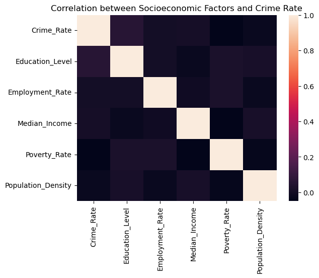

```python
# Heat map of correlation
sns.heatmap(data.corr())
plt.title("Correlation between Socioeconomic Factors and Crime Rate")
plt.show()
```

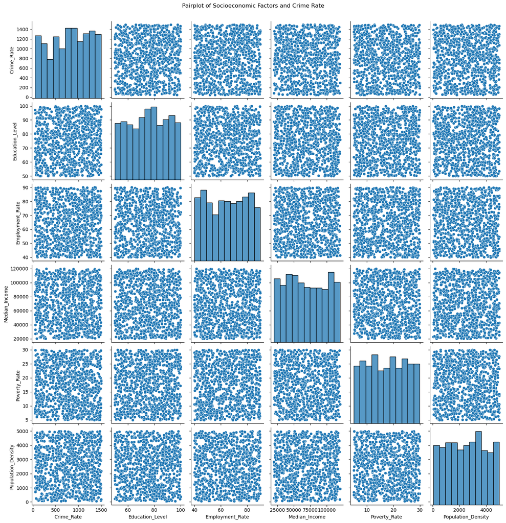

```python
# Pairplot all the data with title and adjusted aesthetics
sns.pairplot(data)
plt.suptitle("Pairplot of Socioeconomic Factors and Crime Rate", y=1.02)
plt.show()
```

## Observation on relationship between socioeconomics factors and crime rate

On both correlation map and pairplot of socioeconomics factors and crime rate, they have uniform distribution between each pair of factors. The factors included in this dataset are possibly too generic for crime rate prediction. Feature engineer must be done to gain more insights. Since this dataset is synthetic to reflect the current state of crime rate in many regions. More data can be added on to create sufficient data insights as long as the new data input is reasonable for the prediction of crime rate.

```python
from sklearn.ensemble import RandomForestRegressor
from sklearn.tree import DecisionTreeRegressor
from sklearn.model_selection import train_test_split
from sklearn.preprocessing import StandardScaler
from sklearn.metrics import mean_squared_error, r2_score, mean_absolute_error, mean_absolute_percentage_error, median_absolute_error
from tabulate import tabulate
import csv
import pickle

def testing_workflow(data, prefix_name):
    results = []

    def train_decision_regressor(max_depth, X_train, y_train, X_test, y_test):
        regressor = DecisionTreeRegressor(max_depth=max_depth, random_state=42)
        regressor.fit(X_train, y_train)

        y_pred = regressor.predict(X_test)
        return evaluate_model(regressor, y_test, y_pred)

    def train_forest_regressor(n_estimators, max_depth, X_train, y_train, X_test, y_test):
        regressor = RandomForestRegressor(max_depth=max_depth, n_estimators=n_estimators, random_state=42)
        regressor.fit(X_train, y_train)

        y_pred = regressor.predict(X_test)
        return evaluate_model(regressor, y_test, y_pred)

    def evaluate_model(regressor, y_test, y_pred):
        mse = mean_squared_error(y_test, y_pred)
        mae = mean_absolute_error(y_test, y_pred)
        r2 = r2_score(y_test, y_pred)
        rmse = np.sqrt(mse)
        mape = mean_absolute_percentage_error(y_test, y_pred)
        median = median_absolute_error(y_test, y_pred)
        return regressor, mse, mae, r2, rmse, mape, median

    for test_portion in [0.2, 0.4, 0.6, 0.8]:  # Use decimal values for percentages
        target = data["Crime_Rate"]
        features = data.drop(columns=["Crime_Rate"])

        X_train, X_test, y_train, y_test = train_test_split(features, target, test_size=test_portion, random_state=42)

        scaler = StandardScaler()
        X_train_scaled = scaler.fit_transform(X_train)
        X_test_scaled = scaler.transform(X_test)

        # Train Decision Tree
        for max_depth in [10, 20, 50, 100]:
            regressor, mse, mae, r2, rmse, mape, median = train_decision_regressor(max_depth, X_train_scaled, y_train, X_test_scaled, y_test)
            pickle.dump(regressor, open(f"models/{prefix_name}_model_{max_depth}_{0}_{int(test_portion * 100)}.pkl", "wb"))
            results.append([test_portion, max_depth, 0, mse, mae, r2, rmse, mape, median])

        # Train Random Forest
        for max_depth in [10, 20, 50, 100]:
            for n_estimators in [10, 20, 50, 100]:
                regressor, mse, mae, r2, rmse, mape, median = train_forest_regressor(n_estimators, max_depth, X_train_scaled, y_train, X_test_scaled, y_test)
                pickle.dump(regressor, open(f"models/{prefix_name}_model_{max_depth}_{n_estimators}_{int(test_portion * 100)}.pkl", "wb"))
                results.append([test_portion, max_depth, n_estimators, mse, mae, r2, rmse, mape, median])

    return results

def save_results_to_csv(results, filename="results.csv"):
    with open(filename, "w", newline="") as f:
        writer = csv.writer(f)
        writer.writerow(["Test Portion", "Max Depth", "n_estimators", "MSE", "MAE", "R2", "RMSE", "MAPE", "Med.AE"])
        writer.writerows(results)

results = testing_workflow(data, "original")

# Display Results
headers = ["Test Portion", "Max Depth", "n_estimators", "MSE", "MAE", "R2", "RMSE", "MAPE", "Med.AE"]
print(tabulate(results, headers=headers, tablefmt="fancy_grid"))

# Save results to CSV
save_results_to_csv(results, "original_results.csv")
```

```
╒════════════════╤═════════════╤════════════════╤════════╤═════════╤════════════╤═════════╤══════════╤══════════╕
│   Test Portion │   Max Depth │   n_estimators │    MSE │     MAE │         R2 │    RMSE │     MAPE │   Med.AE │
╞════════════════╪═════════════╪════════════════╪════════╪═════════╪════════════╪═════════╪══════════╪══════════╡
│            0.2 │          10 │              0 │ 264383 │ 421.741 │ -0.472812  │ 514.182 │ 1.25141  │  377.668 │
├────────────────┼─────────────┼────────────────┼────────┼─────────┼────────────┼─────────┼──────────┼──────────┤
│            0.2 │          20 │              0 │ 374465 │ 496.258 │ -1.08605   │ 611.936 │ 1.32327  │  432     │
├────────────────┼─────────────┼────────────────┼────────┼─────────┼────────────┼─────────┼──────────┼──────────┤
│            0.2 │          50 │              0 │ 370947 │ 501.365 │ -1.06645   │ 609.054 │ 1.31469  │  449     │
├────────────────┼─────────────┼────────────────┼────────┼─────────┼────────────┼─────────┼──────────┼──────────┤
│            0.2 │         100 │              0 │ 370947 │ 501.365 │ -1.06645   │ 609.054 │ 1.31469  │  449     │
├────────────────┼─────────────┼────────────────┼────────┼─────────┼────────────┼─────────┼──────────┼──────────┤
│            0.2 │          10 │             10 │ 199142 │ 378.632 │ -0.10937   │ 446.253 │ 1.1917   │  345.826 │
├────────────────┼─────────────┼────────────────┼────────┼─────────┼────────────┼─────────┼──────────┼──────────┤
│            0.2 │          10 │             20 │ 197741 │ 377.359 │ -0.101569  │ 444.681 │ 1.19529  │  350.777 │
├────────────────┼─────────────┼────────────────┼────────┼─────────┼────────────┼─────────┼──────────┼──────────┤
│            0.2 │          10 │             50 │ 193362 │ 376.826 │ -0.0771725 │ 439.729 │ 1.20688  │  360.834 │
├────────────────┼─────────────┼────────────────┼────────┼─────────┼────────────┼─────────┼──────────┼──────────┤
│            0.2 │          10 │            100 │ 193968 │ 378.313 │ -0.0805511 │ 440.419 │ 1.19988  │  370.448 │
├────────────────┼─────────────┼────────────────┼────────┼─────────┼────────────┼─────────┼──────────┼──────────┤
│            0.2 │          20 │             10 │ 207180 │ 379.5   │ -0.154148  │ 455.17  │ 1.15229  │  346.817 │
├────────────────┼─────────────┼────────────────┼────────┼─────────┼────────────┼─────────┼──────────┼──────────┤
│            0.2 │          20 │             20 │ 204096 │ 378.534 │ -0.136969  │ 451.77  │ 1.19085  │  367.47  │
├────────────────┼─────────────┼────────────────┼────────┼─────────┼────────────┼─────────┼──────────┼──────────┤
│            0.2 │          20 │             50 │ 199565 │ 377.716 │ -0.111727  │ 446.727 │ 1.21616  │  357.588 │
├────────────────┼─────────────┼────────────────┼────────┼─────────┼────────────┼─────────┼──────────┼──────────┤
│            0.2 │          20 │            100 │ 199809 │ 380.189 │ -0.113089  │ 447     │ 1.20219  │  367.193 │
├────────────────┼─────────────┼────────────────┼────────┼─────────┼────────────┼─────────┼──────────┼──────────┤
│            0.2 │          50 │             10 │ 204971 │ 377.007 │ -0.141843  │ 452.737 │ 1.13367  │  351.8   │
├────────────────┼─────────────┼────────────────┼────────┼─────────┼────────────┼─────────┼──────────┼──────────┤
│            0.2 │          50 │             20 │ 203286 │ 378.045 │ -0.132458  │ 450.873 │ 1.18166  │  372.75  │
├────────────────┼─────────────┼────────────────┼────────┼─────────┼────────────┼─────────┼──────────┼──────────┤
│            0.2 │          50 │             50 │ 199411 │ 378.044 │ -0.110871  │ 446.555 │ 1.21555  │  363.39  │
├────────────────┼─────────────┼────────────────┼────────┼─────────┼────────────┼─────────┼──────────┼──────────┤
│            0.2 │          50 │            100 │ 199553 │ 380.678 │ -0.111659  │ 446.713 │ 1.2033   │  367.41  │
├────────────────┼─────────────┼────────────────┼────────┼─────────┼────────────┼─────────┼──────────┼──────────┤
│            0.2 │         100 │             10 │ 204971 │ 377.007 │ -0.141843  │ 452.737 │ 1.13367  │  351.8   │
├────────────────┼─────────────┼────────────────┼────────┼─────────┼────────────┼─────────┼──────────┼──────────┤
│            0.2 │         100 │             20 │ 203286 │ 378.045 │ -0.132458  │ 450.873 │ 1.18166  │  372.75  │
├────────────────┼─────────────┼────────────────┼────────┼─────────┼────────────┼─────────┼──────────┼──────────┤
│            0.2 │         100 │             50 │ 199411 │ 378.044 │ -0.110871  │ 446.555 │ 1.21555  │  363.39  │
```

[output cut: 108 more lines]

```
├────────────────┼─────────────┼────────────────┼────────┼─────────┼────────────┼─────────┼──────────┼──────────┤
│            0.8 │          50 │             20 │ 215451 │ 389.415 │ -0.275398  │ 464.167 │ 1.03208  │  363.975 │
├────────────────┼─────────────┼────────────────┼────────┼─────────┼────────────┼─────────┼──────────┼──────────┤
│            0.8 │          50 │             50 │ 209726 │ 384.916 │ -0.241505  │ 457.958 │ 1.03003  │  362.13  │
├────────────────┼─────────────┼────────────────┼────────┼─────────┼────────────┼─────────┼──────────┼──────────┤
│            0.8 │          50 │            100 │ 204531 │ 381.022 │ -0.210754  │ 452.251 │ 1.02946  │  360.48  │
├────────────────┼─────────────┼────────────────┼────────┼─────────┼────────────┼─────────┼──────────┼──────────┤
│            0.8 │         100 │             10 │ 218089 │ 392.496 │ -0.29101   │ 467     │ 1.03134  │  357.9   │
├────────────────┼─────────────┼────────────────┼────────┼─────────┼────────────┼─────────┼──────────┼──────────┤
│            0.8 │         100 │             20 │ 215451 │ 389.415 │ -0.275398  │ 464.167 │ 1.03208  │  363.975 │
├────────────────┼─────────────┼────────────────┼────────┼─────────┼────────────┼─────────┼──────────┼──────────┤
│            0.8 │         100 │             50 │ 209726 │ 384.916 │ -0.241505  │ 457.958 │ 1.03003  │  362.13  │
├────────────────┼─────────────┼────────────────┼────────┼─────────┼────────────┼─────────┼──────────┼──────────┤
│            0.8 │         100 │            100 │ 204531 │ 381.022 │ -0.210754  │ 452.251 │ 1.02946  │  360.48  │
╘════════════════╧═════════════╧════════════════╧════════╧═════════╧════════════╧═════════╧══════════╧══════════╛
```

```python
# Output top 10 best performing models based on each metric
for metric_idx in [3, 4, 6, 7, 8]:  # Indices for MSE, MAE, RMSE, MAPE, MedAE
    sorted_results = sorted(results, key=lambda x: x[metric_idx])
    top_results = sorted_results[:10]
    print(f"\nTop 10 best performing models based on {headers[metric_idx]}")
    print(tabulate(top_results, headers=headers, tablefmt="pretty_grid"))

# Top 10 by R² (sorted in descending order)
sorted_results = sorted(results, key=lambda x: x[5], reverse=True)  # R² index is 5
top_results = sorted_results[:10]
print(f"\nTop 10 best performing models based on {headers[5]} (R²)")
print(tabulate(top_results, headers=headers, tablefmt="pretty_grid"))
```

```
Top 10 best performing models based on MSE
  Test Portion    Max Depth    n_estimators     MSE      MAE          R2     RMSE      MAPE    Med.AE
--------------  -----------  --------------  ------  -------  ----------  -------  --------  --------
           0.4           10             100  181395  364.125  -0.0686296  425.905  1.01276    342.975
           0.4           10              50  183152  366.063  -0.0789775  427.962  1.01248    343.44
           0.4           20             100  185520  367.661  -0.0929312  430.721  1.01416    351.134
           0.4           50             100  186031  368.536  -0.0959388  431.313  1.01337    348.775
           0.4          100             100  186031  368.536  -0.0959388  431.313  1.01337    348.775
           0.4           20              50  186392  368.17   -0.0980648  431.731  1.01282    352.188
           0.4           10              20  186490  369.043  -0.0986422  431.845  1.0084     357.707
           0.6           10             100  187069  368.33   -0.104866   432.515  0.998079   348.835
           0.4           50              50  187281  369.462  -0.103305   432.76   1.01182    352.02
           0.4          100              50  187281  369.462  -0.103305   432.76   1.01182    352.02

Top 10 best performing models based on MAE
  Test Portion    Max Depth    n_estimators     MSE      MAE          R2     RMSE      MAPE    Med.AE
--------------  -----------  --------------  ------  -------  ----------  -------  --------  --------
           0.4           10             100  181395  364.125  -0.0686296  425.905  1.01276    342.975
           0.4           10              50  183152  366.063  -0.0789775  427.962  1.01248    343.44
           0.4           20             100  185520  367.661  -0.0929312  430.721  1.01416    351.134
           0.4           20              50  186392  368.17   -0.0980648  431.731  1.01282    352.188
           0.6           10             100  187069  368.33   -0.104866   432.515  0.998079   348.835
           0.4           50             100  186031  368.536  -0.0959388  431.313  1.01337    348.775
           0.4          100             100  186031  368.536  -0.0959388  431.313  1.01337    348.775
           0.4           10              20  186490  369.043  -0.0986422  431.845  1.0084     357.707
           0.6           10              20  190191  369.132  -0.123301   436.108  1.00193    349.367
           0.4           50              50  187281  369.462  -0.103305   432.76   1.01182    352.02

Top 10 best performing models based on RMSE
  Test Portion    Max Depth    n_estimators     MSE      MAE          R2     RMSE      MAPE    Med.AE
--------------  -----------  --------------  ------  -------  ----------  -------  --------  --------
           0.4           10             100  181395  364.125  -0.0686296  425.905  1.01276    342.975
           0.4           10              50  183152  366.063  -0.0789775  427.962  1.01248    343.44
           0.4           20             100  185520  367.661  -0.0929312  430.721  1.01416    351.134
           0.4           50             100  186031  368.536  -0.0959388  431.313  1.01337    348.775
           0.4          100             100  186031  368.536  -0.0959388  431.313  1.01337    348.775
           0.4           20              50  186392  368.17   -0.0980648  431.731  1.01282    352.188
           0.4           10              20  186490  369.043  -0.0986422  431.845  1.0084     357.707
           0.6           10             100  187069  368.33   -0.104866   432.515  0.998079   348.835
           0.4           50              50  187281  369.462  -0.103305   432.76   1.01182    352.02
```

[output cut: 28 more lines]

```
           0.4          100             100  186031  368.536  -0.0959388  431.313  1.01337   348.775

Top 10 best performing models based on R2 (R²)
  Test Portion    Max Depth    n_estimators     MSE      MAE          R2     RMSE     MAPE    Med.AE
--------------  -----------  --------------  ------  -------  ----------  -------  -------  --------
           0.4           10             100  181395  364.125  -0.0686296  425.905  1.01276   342.975
           0.2           10              50  193362  376.826  -0.0771725  439.729  1.20688   360.834
           0.4           10              50  183152  366.063  -0.0789775  427.962  1.01248   343.44
           0.2           10             100  193968  378.313  -0.0805511  440.419  1.19988   370.448
           0.4           20             100  185520  367.661  -0.0929312  430.721  1.01416   351.134
           0.4           50             100  186031  368.536  -0.0959388  431.313  1.01337   348.775
           0.4          100             100  186031  368.536  -0.0959388  431.313  1.01337   348.775
           0.4           20              50  186392  368.17   -0.0980648  431.731  1.01282   352.188
           0.4           10              20  186490  369.043  -0.0986422  431.845  1.0084    357.707
           0.2           10              20  197741  377.359  -0.101569   444.681  1.19529   350.777
```

## Regresion with raw data

Observation from the bland sight, all the model's peroformance have negative $R^2$, which mean the prediction is worse than justing guessing the mean of all target values. This is happened because the features are poor. Based on the 5 features: education level, employment rate, median income, poverty rate, population density.

With the target of predicting crime rate, deriving for more socio-economic factors is essential. For this analysis, create a new primary features called region's area to compute the population and other population's properties. The region are are spawn randomly in uniform distribution, the same fashion as the original data, which open paths for further data inferrence.

- Region area: A synthetic uniform distribution to reflect the area in real life. Population can then be computed based on the population density and region's area.
- Total educated people, total poor people, total employed people: The data can be derived from population, plus, mocking the real life inspirations of confidence intervals to create some uncertainties in sampling statistics
- Average income: Assuming there is some skewness in income distribution to reflect the real regione economy, comparing to the median income.
- Crime percentage (actual), total criminals, tracked crime rate: The crime percentage is computed as the number of tracked crime over all population. In real life, There might be more crime that has not been tracked down so the actual crime rate can be higher than the tracked
- Poverty line, inequality ratio, employment to poverty ratio, crime to proverty ratio, crime to education ratio, urbanization and wealth density: These are the ratios and indexes to reflect the socio-economy, that might have some relations to crime rate, but not directly derived from crime rate.

```python
# Initialize new dataframe
derived = pd.DataFrame()

# Input the target "Crime Rate" column
derived["Crime_Rate"] = data["Crime_Rate"]

# create region area with randomization between 0.5 and 250 uniform distribution
derived["Region_Area"] = np.random.uniform(0.5, 250, len(data))

# Average Income (same as Median Income, unless weighted calculation is used)
derived["Average_Income"] = data["Median_Income"]  * np.random.uniform(0.6, 1.5, len(data))

# Compute derived features
derived["Population"] = data["Population_Density"] * derived["Region_Area"]  # Estimate Population

# Total number of people in different categories
derived["Total_Educated"] = (data["Education_Level"] / 100) * derived["Population"] * np.random.uniform(0.7, 1.3, len(data))
derived["Total_Poor"] = (data["Poverty_Rate"] / 100) * derived["Population"] * np.random.uniform(0.7, 1.3, len(data))
derived["Total_Employed"] = (data["Employment_Rate"] / 100) * derived["Population"] * np.random.uniform(0.7, 1.3, len(data))
derived["Tracked_Crime_Rate"] = data["Crime_Rate"] / 100000  * np.random.uniform(0.5, 1.5, len(data))
derived["Total_Criminals"] = derived["Tracked_Crime_Rate"] * derived["Population"]

# Approximate Poverty Line
derived["Poverty_Line"] = data["Median_Income"] * (data["Poverty_Rate"] / 100)

# Inequality Metrics
derived["Inequality_Ratio"] = data["Median_Income"] / derived["Poverty_Line"]
derived["Employment_to_Poverty"] = data["Employment_Rate"] / data["Poverty_Rate"]

# Crime & Socioeconomic Ratios
derived["Crime_to_Poverty_Ratio"] = derived["Tracked_Crime_Rate"] / data["Poverty_Rate"]
derived["Crime_to_Education_Ratio"] = derived["Tracked_Crime_Rate"] / data["Education_Level"]

# Urbanization & Economic Indicators
derived["Urbanization"] = data["Population_Density"] / derived["Region_Area"]
derived["Wealth_Density"] = data["Median_Income"] * data["Population_Density"]

# Display the updated DataFrame
derived.head(n=10)
```

|  | Crime_Rate | Region_Area | Average_Income | Population | Total_Educated | Total_Poor | Total_Employed | Tracked_Crime_Rate | Total_Criminals | Poverty_Line | Inequality_Ratio | Employment_to_Poverty | Crime_to_Poverty_Ratio | Crime_to_Education_Ratio | Urbanization | Wealth_Density |
| --- | --- | --- | --- | --- | --- | --- | --- | --- | --- | --- | --- | --- | --- | --- | --- | --- |
| 0 | 1176 | 190.339206 | 129690.911060 | 289886.610114 | 215296.479109 | 46370.917450 | 270690.921603 | 0.012795 | 3709.077757 | 17097.458983 | 6.823470 | 5.002651 | 0.000873 | 0.000167 | 8.001504 | 177679272 |
| 1 | 910 | 217.025037 | 27585.160992 | 714663.448384 | 435618.906936 | 168213.392836 | 337750.257704 | 0.004717 | 3370.868037 | 4218.698529 | 5.072892 | 2.337999 | 0.000239 | 0.000055 | 15.173365 | 70473493 |
| 2 | 1344 | 15.256743 | 152506.480235 | 69082.530435 | 48391.595699 | 4662.002720 | 50821.747660 | 0.007409 | 511.851452 | 10133.280883 | 10.379560 | 6.633754 | 0.000769 | 0.000084 | 296.786812 | 476250512 |
| 3 | 1180 | 245.972088 | 40438.604103 | 548763.728730 | 303117.357253 | 87639.132787 | 399990.960573 | 0.011371 | 6239.773804 | 7036.587972 | 5.001430 | 3.266203 | 0.000569 | 0.000209 | 9.070135 | 78515583 |
| 4 | 1145 | 114.566576 | 82941.999143 | 171735.296774 | 143186.259220 | 46446.685070 | 63198.561173 | 0.012376 | 2125.420895 | 29825.616010 | 3.768204 | 1.945432 | 0.000466 | 0.000164 | 13.084095 | 168471111 |
| 5 | 1094 | 160.100245 | 93187.842340 | 503675.371239 | 618660.424770 | 97535.605526 | 240761.540840 | 0.010371 | 5223.661983 | 17329.060399 | 3.743077 | 1.646889 | 0.000388 | 0.000107 | 19.650189 | 204062144 |
| 6 | 171 | 180.703422 | 44791.796708 | 597405.511598 | 406226.093758 | 113069.723879 | 540249.894981 | 0.000946 | 565.327207 | 9314.387496 | 4.327391 | 3.411550 | 0.000041 | 0.000014 | 18.295171 | 133254942 |
| 7 | 516 | 80.273704 | 50204.902285 | 257357.496570 | 184123.041559 | 74027.618465 | 145241.819284 | 0.007381 | 1899.428649 | 9365.559275 | 4.229432 | 1.949842 | 0.000312 | 0.000093 | 39.938359 | 126992866 |
| 8 | 1288 | 224.727951 | 42734.565489 | 368553.839633 | 302529.681366 | 64276.376483 | 248670.156651 | 0.010693 | 3941.083542 | 12087.237413 | 5.277550 | 3.679220 | 0.000564 | 0.000156 | 7.297713 | 104617240 |
| 9 | 380 | 5.314441 | 46810.840127 | 22793.637833 | 19331.837004 | 4945.783496 | 15892.935302 | 0.003447 | 78.559206 | 6267.536370 | 5.097697 | 4.425946 | 0.000176 | 0.000047 | 807.046297 | 137033550 |

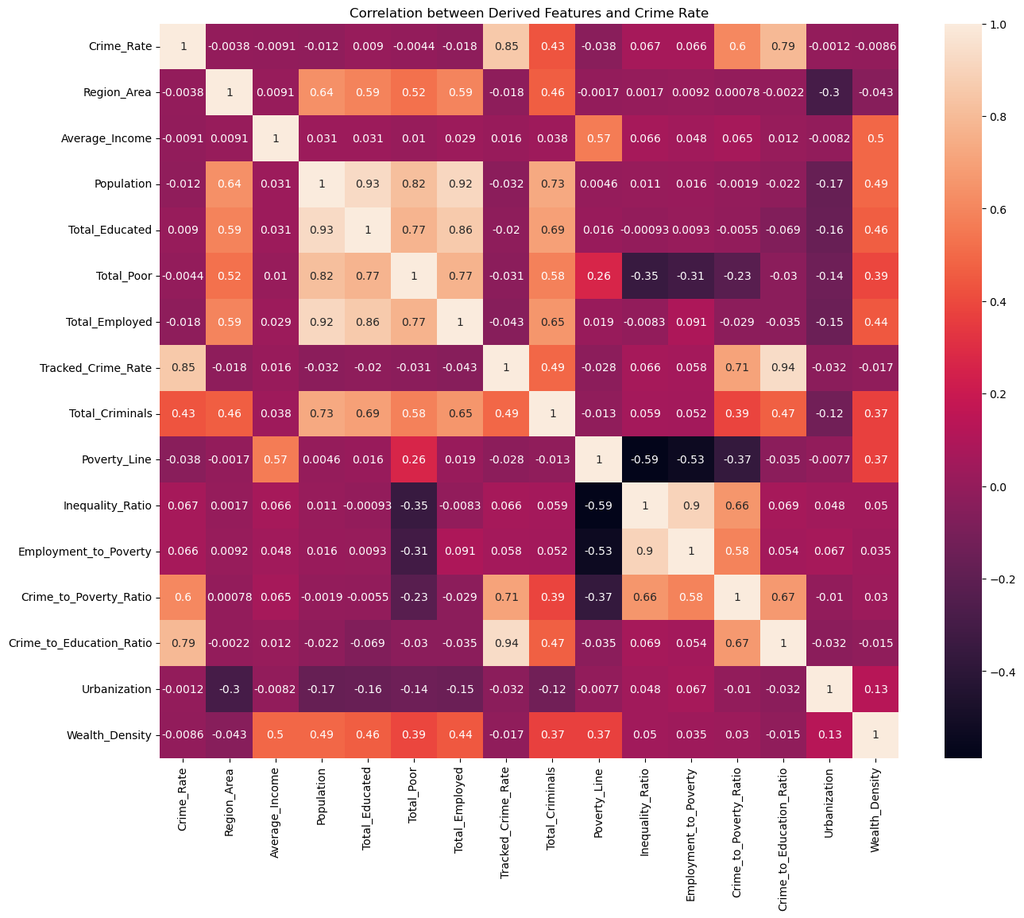

```python
# Correlation between derived features and crime rate
plt.figure(figsize=(15, 12))
sns.heatmap(derived.corr(), annot=True)
plt.title("Correlation between Derived Features and Crime Rate")
plt.show()
```

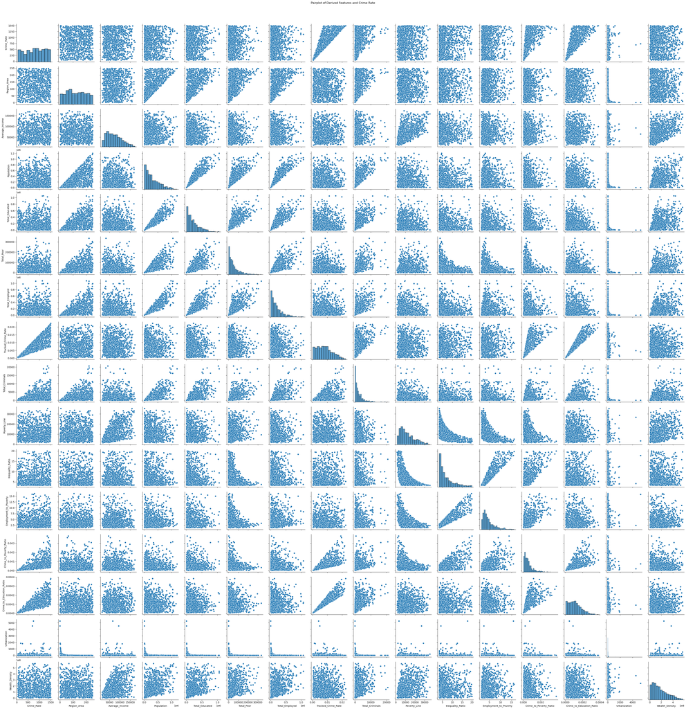

```python
# Get feature names, except "Crime_Rate"
feature_names = [feature for feature in derived.columns if feature != "Crime_Rate"]
# Pairplot all the data with title and adjusted aesthetics
sns.pairplot(derived)
plt.suptitle("Pairplot of Derived Features and Crime Rate", y=1.02)
plt.show()
```

```python
results = testing_workflow(derived, "derived")

# Display Results
headers = ["Test Portion", "Max Depth", "n_estimators", "MSE", "MAE", "R2", "RMSE", "MAPE", "Med.AE"]
print(tabulate(results, headers=headers, tablefmt="fancy_grid"))

# Save results to CSV
save_results_to_csv(results, "derived_results.csv")
```

```
╒════════════════╤═════════════╤════════════════╤═════════╤═════════╤══════════╤═════════╤══════════╤══════════╕
│   Test Portion │   Max Depth │   n_estimators │     MSE │     MAE │       R2 │    RMSE │     MAPE │   Med.AE │
╞════════════════╪═════════════╪════════════════╪═════════╪═════════╪══════════╪═════════╪══════════╪══════════╡
│            0.2 │          10 │              0 │ 61792.3 │ 179.19  │ 0.65577  │ 248.581 │ 0.25601  │  113     │
├────────────────┼─────────────┼────────────────┼─────────┼─────────┼──────────┼─────────┼──────────┼──────────┤
│            0.2 │          20 │              0 │ 72648.4 │ 191.395 │ 0.595293 │ 269.534 │ 0.270428 │  129.5   │
├────────────────┼─────────────┼────────────────┼─────────┼─────────┼──────────┼─────────┼──────────┼──────────┤
│            0.2 │          50 │              0 │ 72648.4 │ 191.395 │ 0.595293 │ 269.534 │ 0.270428 │  129.5   │
├────────────────┼─────────────┼────────────────┼─────────┼─────────┼──────────┼─────────┼──────────┼──────────┤
│            0.2 │         100 │              0 │ 72648.4 │ 191.395 │ 0.595293 │ 269.534 │ 0.270428 │  129.5   │
├────────────────┼─────────────┼────────────────┼─────────┼─────────┼──────────┼─────────┼──────────┼──────────┤
│            0.2 │          10 │             10 │ 40494.8 │ 152.317 │ 0.774414 │ 201.233 │ 0.232678 │  117.864 │
├────────────────┼─────────────┼────────────────┼─────────┼─────────┼──────────┼─────────┼──────────┼──────────┤
│            0.2 │          10 │             20 │ 41077.7 │ 152.177 │ 0.771166 │ 202.676 │ 0.229443 │  111.658 │
├────────────────┼─────────────┼────────────────┼─────────┼─────────┼──────────┼─────────┼──────────┼──────────┤
│            0.2 │          10 │             50 │ 40461   │ 151.673 │ 0.774602 │ 201.149 │ 0.225552 │  122.65  │
├────────────────┼─────────────┼────────────────┼─────────┼─────────┼──────────┼─────────┼──────────┼──────────┤
│            0.2 │          10 │            100 │ 40201.5 │ 151.29  │ 0.776047 │ 200.503 │ 0.224044 │  124.804 │
├────────────────┼─────────────┼────────────────┼─────────┼─────────┼──────────┼─────────┼──────────┼──────────┤
│            0.2 │          20 │             10 │ 43087.3 │ 155.263 │ 0.759971 │ 207.575 │ 0.237017 │  114.6   │
├────────────────┼─────────────┼────────────────┼─────────┼─────────┼──────────┼─────────┼──────────┼──────────┤
│            0.2 │          20 │             20 │ 42799.2 │ 153.705 │ 0.761576 │ 206.88  │ 0.233086 │  112.225 │
├────────────────┼─────────────┼────────────────┼─────────┼─────────┼──────────┼─────────┼──────────┼──────────┤
│            0.2 │          20 │             50 │ 41231   │ 152.07  │ 0.770312 │ 203.054 │ 0.227006 │  122.9   │
├────────────────┼─────────────┼────────────────┼─────────┼─────────┼──────────┼─────────┼──────────┼──────────┤
│            0.2 │          20 │            100 │ 40444.1 │ 151.284 │ 0.774696 │ 201.107 │ 0.223856 │  124.271 │
├────────────────┼─────────────┼────────────────┼─────────┼─────────┼──────────┼─────────┼──────────┼──────────┤
│            0.2 │          50 │             10 │ 42715.1 │ 155.059 │ 0.762045 │ 206.676 │ 0.237025 │  115.4   │
├────────────────┼─────────────┼────────────────┼─────────┼─────────┼──────────┼─────────┼──────────┼──────────┤
│            0.2 │          50 │             20 │ 42695.8 │ 153.663 │ 0.762152 │ 206.63  │ 0.233258 │  112.25  │
├────────────────┼─────────────┼────────────────┼─────────┼─────────┼──────────┼─────────┼──────────┼──────────┤
│            0.2 │          50 │             50 │ 41208.7 │ 152.026 │ 0.770436 │ 202.999 │ 0.227024 │  119.38  │
├────────────────┼─────────────┼────────────────┼─────────┼─────────┼──────────┼─────────┼──────────┼──────────┤
│            0.2 │          50 │            100 │ 40258.2 │ 150.894 │ 0.775732 │ 200.644 │ 0.223473 │  123.905 │
├────────────────┼─────────────┼────────────────┼─────────┼─────────┼──────────┼─────────┼──────────┼──────────┤
│            0.2 │         100 │             10 │ 42715.1 │ 155.059 │ 0.762045 │ 206.676 │ 0.237025 │  115.4   │
├────────────────┼─────────────┼────────────────┼─────────┼─────────┼──────────┼─────────┼──────────┼──────────┤
│            0.2 │         100 │             20 │ 42695.8 │ 153.663 │ 0.762152 │ 206.63  │ 0.233258 │  112.25  │
├────────────────┼─────────────┼────────────────┼─────────┼─────────┼──────────┼─────────┼──────────┼──────────┤
│            0.2 │         100 │             50 │ 41208.7 │ 152.026 │ 0.770436 │ 202.999 │ 0.227024 │  119.38  │
```

[output cut: 108 more lines]

```
├────────────────┼─────────────┼────────────────┼─────────┼─────────┼──────────┼─────────┼──────────┼──────────┤
│            0.8 │          50 │             20 │ 46027.2 │ 167.286 │ 0.727535 │ 214.539 │ 0.248216 │  136.925 │
├────────────────┼─────────────┼────────────────┼─────────┼─────────┼──────────┼─────────┼──────────┼──────────┤
│            0.8 │          50 │             50 │ 46240.9 │ 167.415 │ 0.72627  │ 215.037 │ 0.250163 │  134.84  │
├────────────────┼─────────────┼────────────────┼─────────┼─────────┼──────────┼─────────┼──────────┼──────────┤
│            0.8 │          50 │            100 │ 46365.4 │ 167.456 │ 0.725532 │ 215.326 │ 0.250263 │  137.885 │
├────────────────┼─────────────┼────────────────┼─────────┼─────────┼──────────┼─────────┼──────────┼──────────┤
│            0.8 │         100 │             10 │ 46958.6 │ 167.72  │ 0.722021 │ 216.699 │ 0.249728 │  133.9   │
├────────────────┼─────────────┼────────────────┼─────────┼─────────┼──────────┼─────────┼──────────┼──────────┤
│            0.8 │         100 │             20 │ 46027.2 │ 167.286 │ 0.727535 │ 214.539 │ 0.248216 │  136.925 │
├────────────────┼─────────────┼────────────────┼─────────┼─────────┼──────────┼─────────┼──────────┼──────────┤
│            0.8 │         100 │             50 │ 46240.9 │ 167.415 │ 0.72627  │ 215.037 │ 0.250163 │  134.84  │
├────────────────┼─────────────┼────────────────┼─────────┼─────────┼──────────┼─────────┼──────────┼──────────┤
│            0.8 │         100 │            100 │ 46365.4 │ 167.456 │ 0.725532 │ 215.326 │ 0.250263 │  137.885 │
╘════════════════╧═════════════╧════════════════╧═════════╧═════════╧══════════╧═════════╧══════════╧══════════╛
```

```python
# Output top 10 best performing models based on MSE
best_models = []
for metric_idx in [3, 4, 6, 7, 8]:  # Indices for MSE, MAE, RMSE, MAPE, MedAE
    sorted_results = sorted(results, key=lambda x: x[metric_idx])
    top_results = sorted_results[:10]
    print(f"\nTop 10 best performing models based on {headers[metric_idx]}")
    print(tabulate(top_results, headers=headers, tablefmt="pretty_grid"))
    best_models.append(f"models/derived_model_{top_results[0][1]}_{top_results[0][2]}_{int(top_results[0][0] * 100)}")


# Top 10 by R² (sorted in descending order)
sorted_results = sorted(results, key=lambda x: x[5], reverse=True)  # R² index is 5
top_results = sorted_results[:10]
print(f"\nTop 10 best performing models based on {headers[5]} (R²)")
print(tabulate(top_results, headers=headers, tablefmt="pretty_grid"))
```

```
Top 10 best performing models based on MSE
  Test Portion    Max Depth    n_estimators      MSE      MAE        R2     RMSE      MAPE    Med.AE
--------------  -----------  --------------  -------  -------  --------  -------  --------  --------
           0.2           10             100  40201.5  151.29   0.776047  200.503  0.224044   124.804
           0.2           50             100  40258.2  150.894  0.775732  200.644  0.223473   123.905
           0.2          100             100  40258.2  150.894  0.775732  200.644  0.223473   123.905
           0.2           20             100  40444.1  151.284  0.774696  201.107  0.223856   124.271
           0.2           10              50  40461    151.673  0.774602  201.149  0.225552   122.65
           0.2           10              10  40494.8  152.317  0.774414  201.233  0.232678   117.864
           0.2           10              20  41077.7  152.177  0.771166  202.676  0.229443   111.658
           0.6           20             100  41129.2  155.15   0.757083  202.803  0.22233    121.35
           0.6           50             100  41166.1  155.195  0.756865  202.894  0.222314   122.135
           0.6          100             100  41166.1  155.195  0.756865  202.894  0.222314   122.135

Top 10 best performing models based on MAE
  Test Portion    Max Depth    n_estimators      MSE      MAE        R2     RMSE      MAPE    Med.AE
--------------  -----------  --------------  -------  -------  --------  -------  --------  --------
           0.2           50             100  40258.2  150.894  0.775732  200.644  0.223473   123.905
           0.2          100             100  40258.2  150.894  0.775732  200.644  0.223473   123.905
           0.2           20             100  40444.1  151.284  0.774696  201.107  0.223856   124.271
           0.2           10             100  40201.5  151.29   0.776047  200.503  0.224044   124.804
           0.2           10              50  40461    151.673  0.774602  201.149  0.225552   122.65
           0.2           50              50  41208.7  152.026  0.770436  202.999  0.227024   119.38
           0.2          100              50  41208.7  152.026  0.770436  202.999  0.227024   119.38
           0.2           20              50  41231    152.07   0.770312  203.054  0.227006   122.9
           0.2           10              20  41077.7  152.177  0.771166  202.676  0.229443   111.658
           0.2           10              10  40494.8  152.317  0.774414  201.233  0.232678   117.864

Top 10 best performing models based on RMSE
  Test Portion    Max Depth    n_estimators      MSE      MAE        R2     RMSE      MAPE    Med.AE
--------------  -----------  --------------  -------  -------  --------  -------  --------  --------
           0.2           10             100  40201.5  151.29   0.776047  200.503  0.224044   124.804
           0.2           50             100  40258.2  150.894  0.775732  200.644  0.223473   123.905
           0.2          100             100  40258.2  150.894  0.775732  200.644  0.223473   123.905
           0.2           20             100  40444.1  151.284  0.774696  201.107  0.223856   124.271
           0.2           10              50  40461    151.673  0.774602  201.149  0.225552   122.65
           0.2           10              10  40494.8  152.317  0.774414  201.233  0.232678   117.864
           0.2           10              20  41077.7  152.177  0.771166  202.676  0.229443   111.658
           0.6           20             100  41129.2  155.15   0.757083  202.803  0.22233    121.35
           0.6           50             100  41166.1  155.195  0.756865  202.894  0.222314   122.135
```

[output cut: 28 more lines]

```
           0.2           50              50  41208.7  152.026  0.770436  202.999  0.227024   119.38

Top 10 best performing models based on R2 (R²)
  Test Portion    Max Depth    n_estimators      MSE      MAE        R2     RMSE      MAPE    Med.AE
--------------  -----------  --------------  -------  -------  --------  -------  --------  --------
           0.2           10             100  40201.5  151.29   0.776047  200.503  0.224044   124.804
           0.2           50             100  40258.2  150.894  0.775732  200.644  0.223473   123.905
           0.2          100             100  40258.2  150.894  0.775732  200.644  0.223473   123.905
           0.2           20             100  40444.1  151.284  0.774696  201.107  0.223856   124.271
           0.2           10              50  40461    151.673  0.774602  201.149  0.225552   122.65
           0.2           10              10  40494.8  152.317  0.774414  201.233  0.232678   117.864
           0.2           10              20  41077.7  152.177  0.771166  202.676  0.229443   111.658
           0.2           50              50  41208.7  152.026  0.770436  202.999  0.227024   119.38
           0.2          100              50  41208.7  152.026  0.770436  202.999  0.227024   119.38
           0.2           20              50  41231    152.07   0.770312  203.054  0.227006   122.9
```

## Regresion with derived data

Observation from the bland sight, all the model's performance has about 0.70 value on $R^2$, which means the model perform predictions on crime rate better than making predictions based on the original dataset. The heatmap of correlation and pair plot matrix show more possible way to better predict the crime rate based on the derived data and indecies. There might be a lot of redundant features, which bias the decision making and damage the regression outcomes. The most dominant factor for making regression prediction is based on the tracked crime rate to overshoot to the actual crime rate. Other factors are minimal to decision making. Random forest regressor has very little correlation to performance metrics (MSE, MAE, R2, RMSE, MAPE, Med.AE) to the model's hyper-parameters and testing portions.

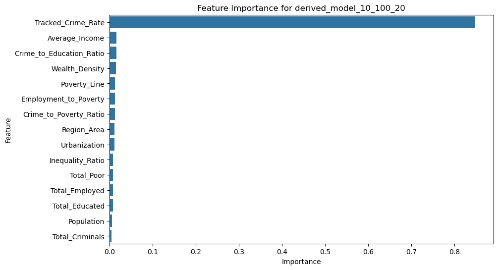

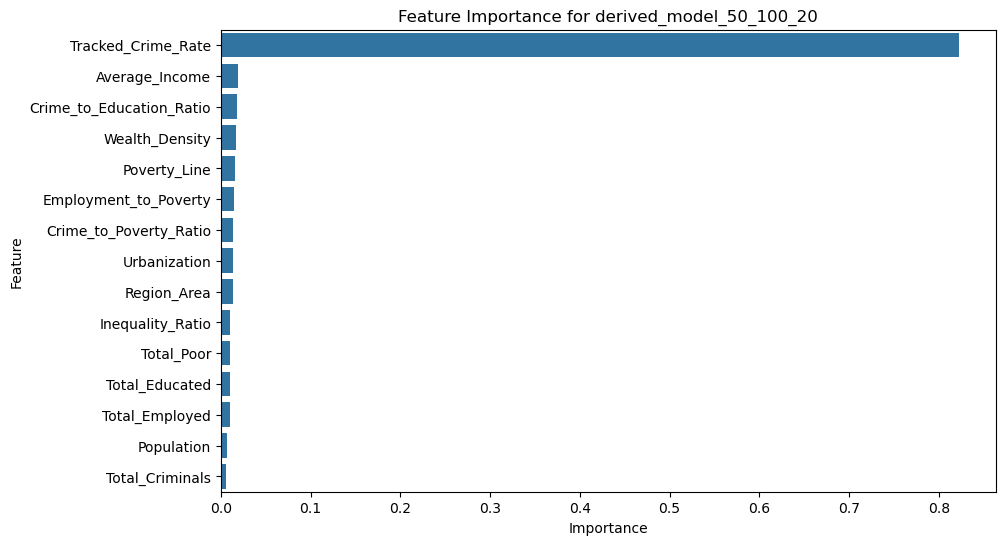

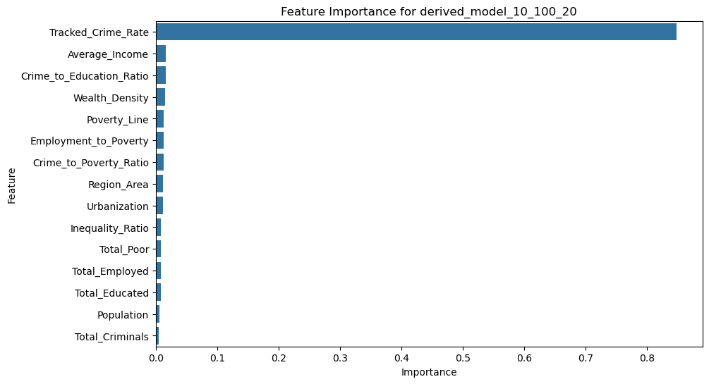

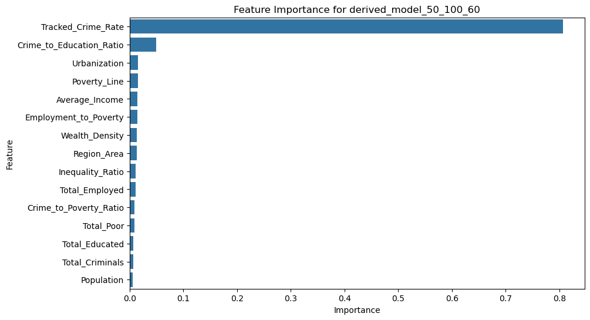

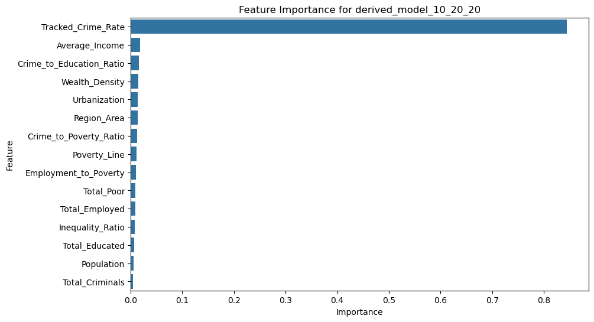

```python
for model_filename in best_models:
    try:
        model = pickle.load(open(f"{model_filename}.pkl", "rb"))

        if isinstance(model, (DecisionTreeRegressor, RandomForestRegressor)):

            if len(feature_names) == len(model.feature_importances_):
                feature_importances = pd.DataFrame({"Feature": feature_names, "Importance": model.feature_importances_})
                feature_importances = feature_importances.sort_values(by="Importance", ascending=False)

                # Plot Feature Importances
                plt.figure(figsize=(10, 6))
                sns.barplot(x="Importance", y="Feature", data=feature_importances)
                plt.title(f"Feature Importance for {model_filename}")
                plt.xlabel("Importance")
                plt.ylabel("Feature")
                plt.show()
            else:
                print(f"Feature mismatch: Expected {len(model.feature_importances_)} features, but got {len(feature_names)}.")
        else:
            print(f"Model {model_filename} does not support feature importance.")

    except FileNotFoundError:
        print(f"Model file {model_filename}.pkl not found.")
    except AttributeError as e:
        print(f"Error loading feature importances for {model_filename}: {e}")
```

```
Selected Features using RFE: ['Average_Income', 'Total_Employed', 'Tracked_Crime_Rate', 'Employment_to_Poverty', 'Crime_to_Education_Ratio']
```

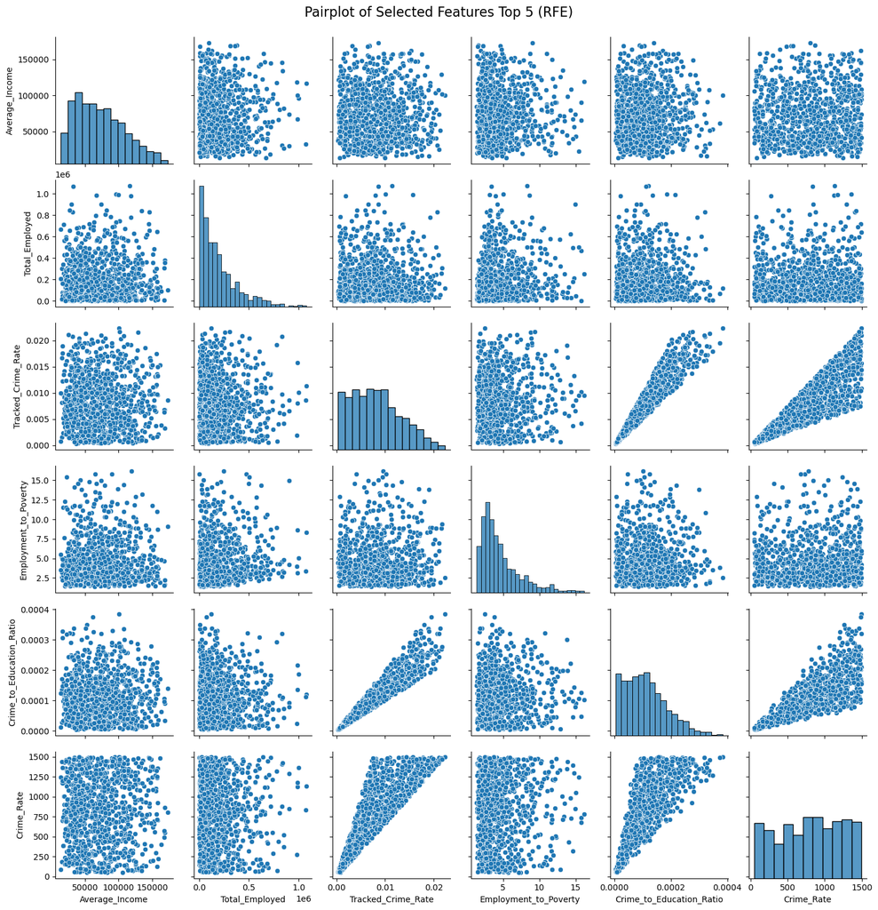

```
Selected Features using SelectKBest: ['Tracked_Crime_Rate', 'Total_Criminals', 'Inequality_Ratio', 'Crime_to_Poverty_Ratio', 'Crime_to_Education_Ratio']
```

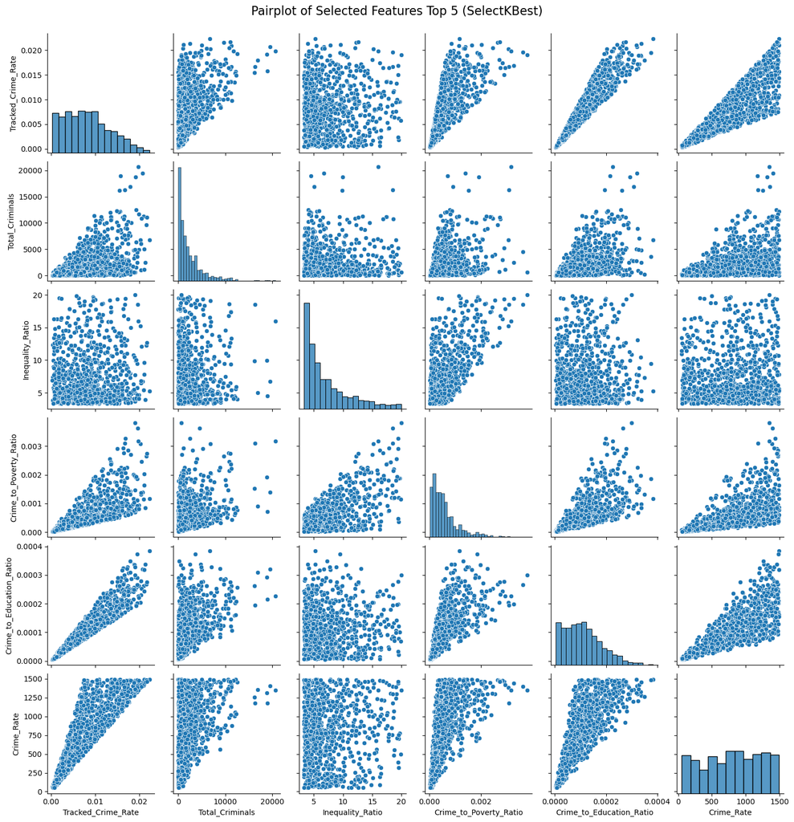

```
Top Features based on Mutual Information:
Tracked_Crime_Rate          1.003763
Crime_to_Education_Ratio    0.741737
Crime_to_Poverty_Ratio      0.559054
Total_Criminals             0.187527
Urbanization                0.016773
dtype: float64
```

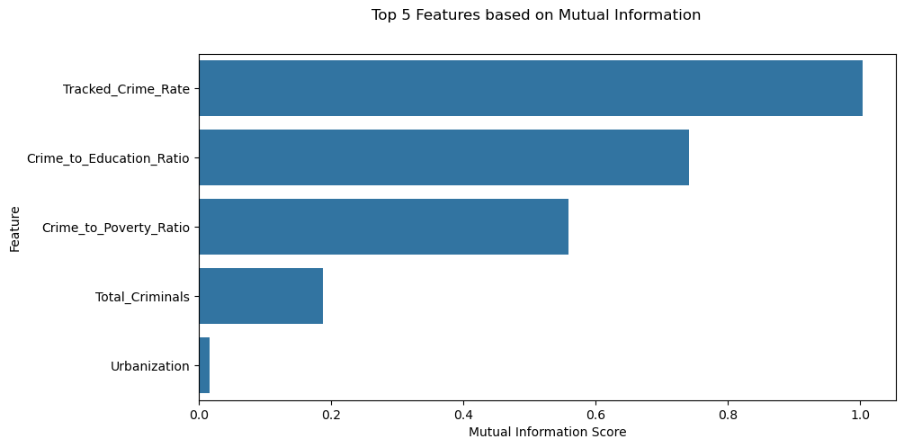

```
Final Selected Features: ['Crime_to_Poverty_Ratio', 'Inequality_Ratio', 'Tracked_Crime_Rate', 'Employment_to_Poverty', 'Crime_to_Education_Ratio', 'Total_Criminals', 'Total_Employed', 'Urbanization', 'Average_Income']
```

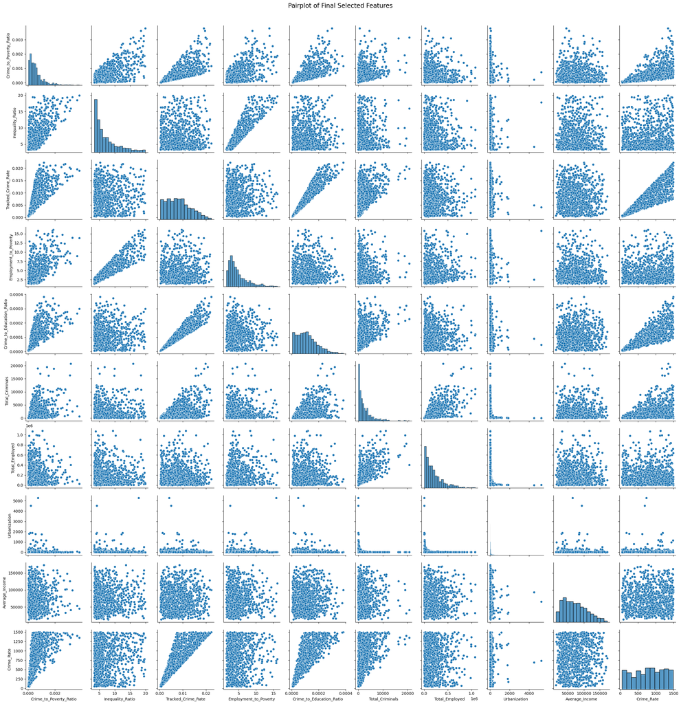

```python
# Feature selection
from sklearn.feature_selection import SelectKBest, f_regression, RFE, mutual_info_regression
from sklearn.ensemble import RandomForestRegressor

# Initialize model
estimator = RandomForestRegressor(n_estimators=100, random_state=42)

num_top_features = 5

# Perform RFE
rfe = RFE(estimator, n_features_to_select=num_top_features)  # Select top features
X_rfe = rfe.fit_transform(derived[feature_names], derived["Crime_Rate"])
rfe_features = [feature_names[i] for i in rfe.get_support(indices=True)]

# Display selected features
print("Selected Features using RFE:", rfe_features)

# Plot Pairplot
plt.figure(figsize=(12, 15))
sns.pairplot(derived[rfe_features + ["Crime_Rate"]])
plt.suptitle(f"Pairplot of Selected Features Top {num_top_features} (RFE)", fontsize = 16, y=1.02)
plt.show()

# Ensure all selected features are numeric
feature_names = [col for col in derived.columns if col not in ["Region", "Crime_Rate"]]  # Exclude non-numeric columns

# Perform feature selection
selector = SelectKBest(score_func=f_regression, k=num_top_features)  # Select top features
X_selected = selector.fit_transform(derived[feature_names], derived["Crime_Rate"])
selected_features = [feature_names[i] for i in selector.get_support(indices=True)]

# Display selected features
print("Selected Features using SelectKBest:", selected_features)

# Plot Pairplot
plt.figure(figsize=(12, 15))
sns.pairplot(derived[selected_features + ["Crime_Rate"]])
plt.suptitle(f"Pairplot of Selected Features Top {num_top_features} (SelectKBest)", fontsize = 16, y=1.02)
plt.show()

# Compute mutual information scores
mi_scores = mutual_info_regression(derived[feature_names], derived["Crime_Rate"])
mi_scores_series = pd.Series(mi_scores, index=feature_names).sort_values(ascending=False)

# Display top features
print("Top Features based on Mutual Information:")
print(mi_scores_series.head(num_top_features))

# Plot feature importance
plt.figure(figsize=(10, 5))
sns.barplot(x=mi_scores_series.head(num_top_features), y=mi_scores_series.head(num_top_features).index)
plt.xlabel("Mutual Information Score")
plt.ylabel("Feature")
plt.suptitle(f"Top {num_top_features} Features based on Mutual Information")
plt.show()

# Combine selected features
final_selected_features = list(set(selected_features + rfe_features + mi_scores_series.head(num_top_features).index.tolist()))

print("Final Selected Features:", final_selected_features)

# Filter dataset to only use selected features
X_final = derived[final_selected_features]

# Plot Pairplot
plt.figure(figsize=(12, 15))
sns.pairplot(derived[final_selected_features + ["Crime_Rate"]])
plt.suptitle("Pairplot of Final Selected Features", fontsize = 16, y=1.02)
plt.show()
```

## Feature selection for better regression performance

Three feature selection models are used in this analysis are recursive feature elimination, select K best and mutual information regression. The goal is to cross check the most impactful features for better regression models.

- The recursive feature elimination model finds top 5 features: average income, total emplyed people, tracked crime rate, employment to poverty, and crime to education ratio.
- The select K best model finds top 5 features: tracked crime rate, total criminals, inequality ratio, crime to poverty ratio, and crime to education ratio.
- Mutual information models finds top 5 features: tracked crime rate, crime to education ratio, crime to poverty ratio, total criminals, and urbanization.

The final decision is to collect all features for the final test on regression predictions. The 3 candidates are linear regressor, random forest regressor, and decision tree regressor. They are used to train and predict the output based on different testing parameters and their own hyper-parameters. Choosing the best model for accurate predication will wrap up this analysis.

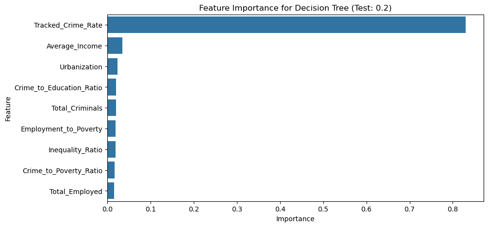

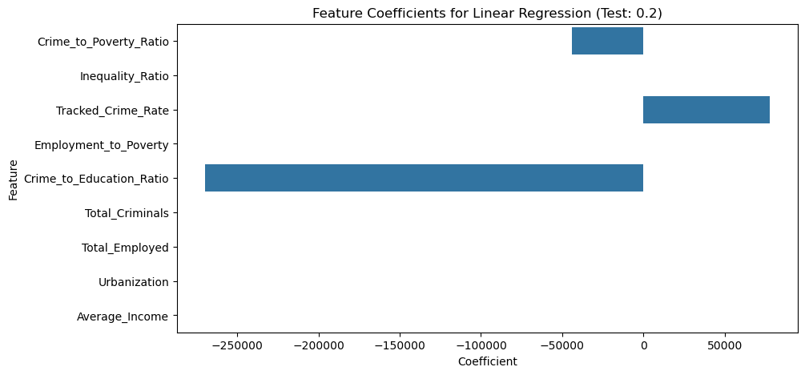

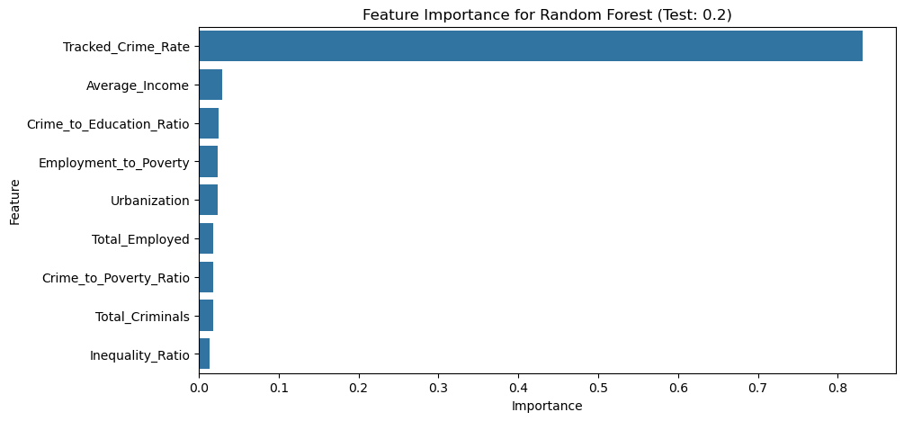

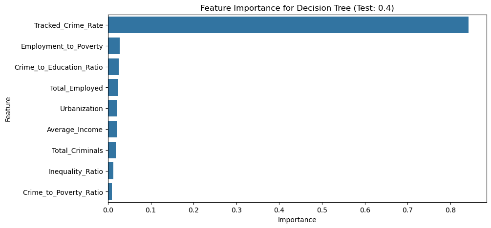

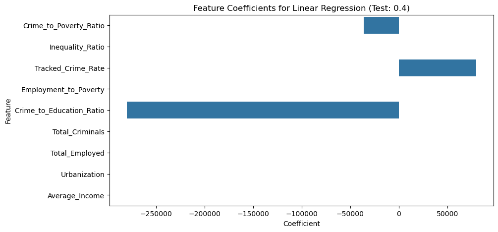

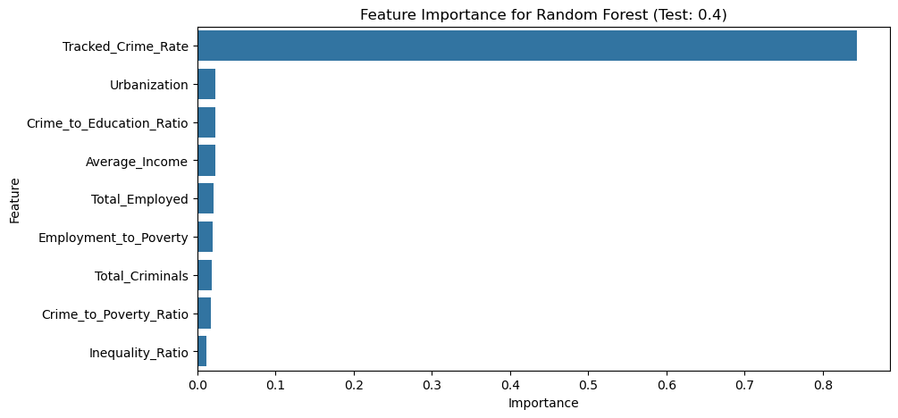

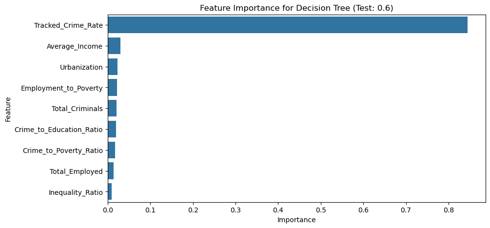

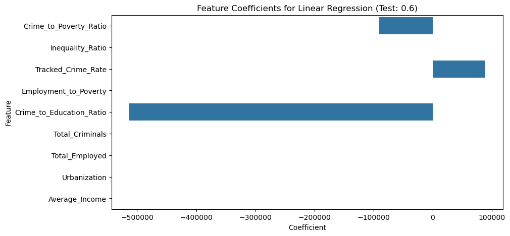

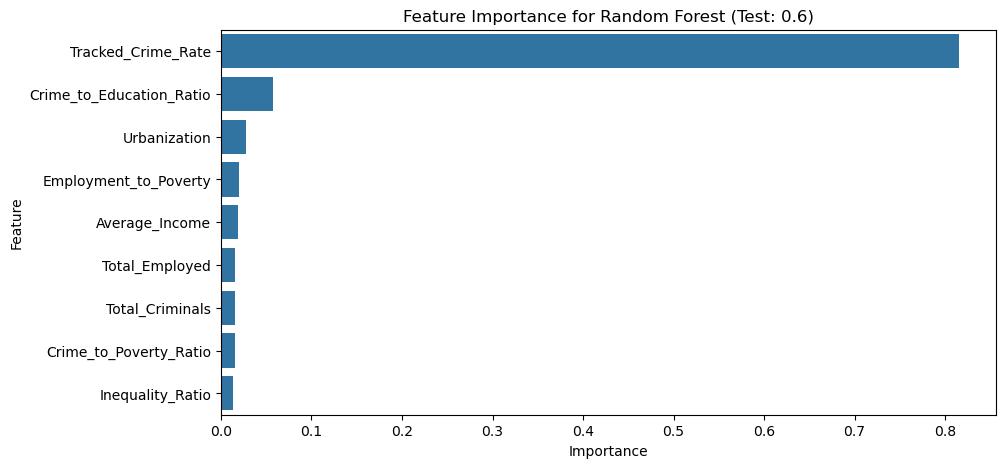

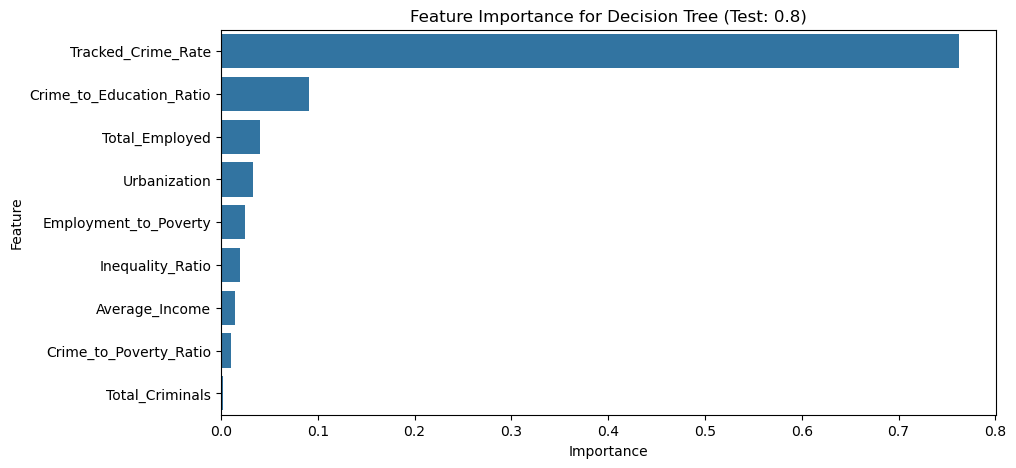

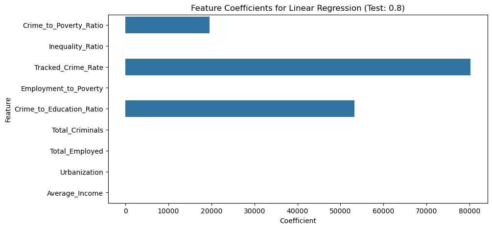

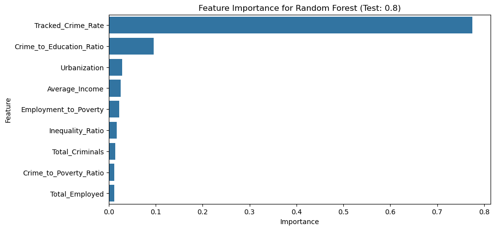

```
╒════╤═══════════════════════════════════════════════╤═════════╤═════════╤══════════╤═════════╤══════════╤═════════════════╕
│    │ Model                                         │     MSE │     MAE │       R2 │    RMSE │     MAPE │   Overall Score │
╞════╪═══════════════════════════════════════════════╪═════════╪═════════╪══════════╪═════════╪══════════╪═════════════════╡
│  7 │ Random Forest (Test: 0.2, Depth: 5, Est: 15)  │ 38641.5 │ 148.285 │ 0.784737 │ 196.575 │ 0.217887 │        4.77374  │
├────┼───────────────────────────────────────────────┼─────────┼─────────┼──────────┼─────────┼──────────┼─────────────────┤
│  8 │ Random Forest (Test: 0.2, Depth: 5, Est: 20)  │ 38904.1 │ 148.164 │ 0.783275 │ 197.241 │ 0.216539 │        4.77128  │
├────┼───────────────────────────────────────────────┼─────────┼─────────┼──────────┼─────────┼──────────┼─────────────────┤
│  5 │ Random Forest (Test: 0.2, Depth: 5, Est: 5)   │ 38587.5 │ 148.874 │ 0.785038 │ 196.437 │ 0.219246 │        4.76144  │
├────┼───────────────────────────────────────────────┼─────────┼─────────┼──────────┼─────────┼──────────┼─────────────────┤
│  6 │ Random Forest (Test: 0.2, Depth: 5, Est: 10)  │ 38826.2 │ 148.826 │ 0.783709 │ 197.044 │ 0.218109 │        4.75796  │
├────┼───────────────────────────────────────────────┼─────────┼─────────┼──────────┼─────────┼──────────┼─────────────────┤
│ 50 │ Random Forest (Test: 0.6, Depth: 5, Est: 20)  │ 40558.2 │ 155.588 │ 0.760456 │ 201.391 │ 0.221815 │        4.56728  │
├────┼───────────────────────────────────────────────┼─────────┼─────────┼──────────┼─────────┼──────────┼─────────────────┤
│ 49 │ Random Forest (Test: 0.6, Depth: 5, Est: 15)  │ 40923.2 │ 156.202 │ 0.7583   │ 202.295 │ 0.221945 │        4.54335  │
├────┼───────────────────────────────────────────────┼─────────┼─────────┼──────────┼─────────┼──────────┼─────────────────┤
│ 48 │ Random Forest (Test: 0.6, Depth: 5, Est: 10)  │ 41383.2 │ 157.595 │ 0.755583 │ 203.429 │ 0.224281 │        4.49371  │
├────┼───────────────────────────────────────────────┼─────────┼─────────┼──────────┼─────────┼──────────┼─────────────────┤
│ 15 │ Random Forest (Test: 0.2, Depth: 15, Est: 15) │ 43009.3 │ 152.388 │ 0.760406 │ 207.387 │ 0.22743  │        4.48376  │
├────┼───────────────────────────────────────────────┼─────────┼─────────┼──────────┼─────────┼──────────┼─────────────────┤
│  0 │ Decision Tree (Test: 0.2, Depth: 5)           │ 42355   │ 155.07  │ 0.76405  │ 205.803 │ 0.228434 │        4.47358  │
├────┼───────────────────────────────────────────────┼─────────┼─────────┼──────────┼─────────┼──────────┼─────────────────┤
│ 19 │ Random Forest (Test: 0.2, Depth: 20, Est: 15) │ 43324.5 │ 152.974 │ 0.75865  │ 208.145 │ 0.228859 │        4.45541  │
├────┼───────────────────────────────────────────────┼─────────┼─────────┼──────────┼─────────┼──────────┼─────────────────┤
│ 16 │ Random Forest (Test: 0.2, Depth: 15, Est: 20) │ 43696.8 │ 153.087 │ 0.756576 │ 209.038 │ 0.226166 │        4.45325  │
├────┼───────────────────────────────────────────────┼─────────┼─────────┼──────────┼─────────┼──────────┼─────────────────┤
│ 20 │ Random Forest (Test: 0.2, Depth: 20, Est: 20) │ 43977.8 │ 154.322 │ 0.75501  │ 209.709 │ 0.228699 │        4.41243  │
├────┼───────────────────────────────────────────────┼─────────┼─────────┼──────────┼─────────┼──────────┼─────────────────┤
│ 29 │ Random Forest (Test: 0.4, Depth: 5, Est: 20)  │ 42446.4 │ 158.75  │ 0.749941 │ 206.025 │ 0.230518 │        4.4001   │
├────┼───────────────────────────────────────────────┼─────────┼─────────┼──────────┼─────────┼──────────┼─────────────────┤
│ 11 │ Random Forest (Test: 0.2, Depth: 10, Est: 15) │ 44534.4 │ 154.73  │ 0.75191  │ 211.032 │ 0.23004  │        4.37664  │
├────┼───────────────────────────────────────────────┼─────────┼─────────┼──────────┼─────────┼──────────┼─────────────────┤
│ 28 │ Random Forest (Test: 0.4, Depth: 5, Est: 15)  │ 43010.6 │ 159.135 │ 0.746618 │ 207.39  │ 0.23143  │        4.36627  │
├────┼───────────────────────────────────────────────┼─────────┼─────────┼──────────┼─────────┼──────────┼─────────────────┤
│ 12 │ Random Forest (Test: 0.2, Depth: 10, Est: 20) │ 44736.7 │ 155.333 │ 0.750783 │ 211.511 │ 0.229605 │        4.36327  │
├────┼───────────────────────────────────────────────┼─────────┼─────────┼──────────┼─────────┼──────────┼─────────────────┤
│ 47 │ Random Forest (Test: 0.6, Depth: 5, Est: 5)   │ 43346.4 │ 159.384 │ 0.743988 │ 208.198 │ 0.228928 │        4.36215  │
├────┼───────────────────────────────────────────────┼─────────┼─────────┼──────────┼─────────┼──────────┼─────────────────┤
│ 58 │ Random Forest (Test: 0.6, Depth: 15, Est: 20) │ 43551.3 │ 159.145 │ 0.742778 │ 208.69  │ 0.228224 │        4.36022  │
├────┼───────────────────────────────────────────────┼─────────┼─────────┼──────────┼─────────┼──────────┼─────────────────┤
│ 57 │ Random Forest (Test: 0.6, Depth: 15, Est: 15) │ 43592.9 │ 159.153 │ 0.742532 │ 208.789 │ 0.22847  │        4.35699  │
```

[output cut: 116 more lines]

```
├────┼───────────────────────────────────────────────┼─────────┼─────────┼──────────┼─────────┼──────────┼─────────────────┤
│ 44 │ Decision Tree (Test: 0.6, Depth: 15)          │ 75856.1 │ 207.351 │ 0.55198  │ 275.42  │ 0.293031 │        2.13266  │
├────┼───────────────────────────────────────────────┼─────────┼─────────┼──────────┼─────────┼──────────┼─────────────────┤
│ 23 │ Decision Tree (Test: 0.4, Depth: 15)          │ 78058.4 │ 202.074 │ 0.540145 │ 279.389 │ 0.295266 │        2.10238  │
├────┼───────────────────────────────────────────────┼─────────┼─────────┼──────────┼─────────┼──────────┼─────────────────┤
│ 45 │ Decision Tree (Test: 0.6, Depth: 20)          │ 76608.3 │ 208.442 │ 0.547537 │ 276.782 │ 0.29446  │        2.08323  │
├────┼───────────────────────────────────────────────┼─────────┼─────────┼──────────┼─────────┼──────────┼─────────────────┤
│ 24 │ Decision Tree (Test: 0.4, Depth: 20)          │ 83029   │ 209.365 │ 0.510862 │ 288.147 │ 0.303964 │        1.78102  │
├────┼───────────────────────────────────────────────┼─────────┼─────────┼──────────┼─────────┼──────────┼─────────────────┤
│ 64 │ Decision Tree (Test: 0.8, Depth: 10)          │ 96484.7 │ 228.854 │ 0.428843 │ 310.62  │ 0.332286 │        0.895264 │
├────┼───────────────────────────────────────────────┼─────────┼─────────┼──────────┼─────────┼──────────┼─────────────────┤
│ 66 │ Decision Tree (Test: 0.8, Depth: 20)          │ 99257   │ 230.972 │ 0.412432 │ 315.051 │ 0.330432 │        0.780506 │
├────┼───────────────────────────────────────────────┼─────────┼─────────┼──────────┼─────────┼──────────┼─────────────────┤
│ 65 │ Decision Tree (Test: 0.8, Depth: 15)          │ 99257   │ 230.972 │ 0.412432 │ 315.051 │ 0.330432 │        0.780506 │
╘════╧═══════════════════════════════════════════════╧═════════╧═════════╧══════════╧═════════╧══════════╧═════════════════╛
```

```python
from sklearn.linear_model import LinearRegression

results = []

def evaluate_model(model, X, y, title):
    y_pred = model.predict(X)
    mse = mean_squared_error(y, y_pred)
    mae = mean_absolute_error(y, y_pred)
    r2 = r2_score(y, y_pred)
    rmse = np.sqrt(mse)
    mape = np.mean(np.abs((y - y_pred) / y))

    results.append([title, mse, mae, r2, rmse, mape])

def plot_feature_importance(model, X, title):
    if hasattr(model, "feature_importances_"):
        feature_importances = pd.DataFrame({"Importance": model.feature_importances_, "Feature": X.columns})
        feature_importances.sort_values(by="Importance", ascending=False, inplace=True)

        plt.figure(figsize=(10, 5))
        sns.barplot(x="Importance", y="Feature", data=feature_importances)
        plt.xlabel("Importance")
        plt.ylabel("Feature")
        plt.title(title)
        plt.show()

for test_portion in [0.2, 0.4, 0.6, 0.8]:
    X_train, X_test, y_train, y_test = train_test_split(X_final, derived["Crime_Rate"], test_size=test_portion, random_state=42)

    # Decision Tree
    for max_depth in [5, 10, 15, 20]:
        model = DecisionTreeRegressor(random_state=42, max_depth=max_depth)
        model.fit(X_train, y_train)
        evaluate_model(model, X_test, y_test, f"Decision Tree (Test: {test_portion}, Depth: {max_depth})")
    plot_feature_importance(model, X_train, f"Feature Importance for Decision Tree (Test: {test_portion})")

    # Linear Regression
    model = LinearRegression()
    model.fit(X_train, y_train)
    evaluate_model(model, X_test, y_test, f"Linear Regression (Test: {test_portion})")
    # Plot feature coefficients
    plt.figure(figsize=(10, 5))
    sns.barplot(x=model.coef_, y=X_train.columns)
    plt.xlabel("Coefficient")
    plt.ylabel("Feature")
    plt.title(f"Feature Coefficients for Linear Regression (Test: {test_portion})")
    plt.show()

    # Random Forest
    for max_depth in [5, 10, 15, 20]:
        for n_estimators in [5, 10, 15, 20]:
            model = RandomForestRegressor(random_state=42, n_estimators=n_estimators, max_depth=max_depth)
            model.fit(X_train, y_train)
            evaluate_model(model, X_test, y_test, f"Random Forest (Test: {test_portion}, Depth: {max_depth}, Est: {n_estimators})")
    plot_feature_importance(model, X_train, f"Feature Importance for Random Forest (Test: {test_portion})")

# Convert to DataFrame
df_results = pd.DataFrame(results, columns=["Model", "MSE", "MAE", "R2", "RMSE", "MAPE"])

# Normalize MSE, MAE, RMSE, and MAPE between 0 and 1
for col in ["MSE", "MAE", "RMSE", "MAPE"]:
    df_results[f"Scaled_{col}"] = (df_results[col] - df_results[col].min()) / (df_results[col].max() - df_results[col].min())

# Compute overall score
df_results["Overall_Score"] = df_results["R2"] + 4 - df_results["Scaled_MSE"] - df_results["Scaled_MAE"] - df_results["Scaled_RMSE"] - df_results["Scaled_MAPE"]

# Sort by overall score
df_results.sort_values(by="Overall_Score", ascending=False, inplace=True)

# Print results
headers = ["Model", "MSE", "MAE", "R2", "RMSE", "MAPE", "Overall Score"]
print(tabulate(df_results[["Model", "MSE", "MAE", "R2", "RMSE", "MAPE", "Overall_Score"]], headers=headers, tablefmt="fancy_grid"))
```

## Model selection

Based on the graph of feature important and feature coefficients, the tracked crime rate is the main component used to predict the actual crime rate. It is similar to making guesses of actual crime rate based on the current crime rate and other minor supporting factor such as average income, crime to poverty ratio, crime to education ratio, urbanization index, and employment to poverty ratio.